# Introduction to R

Introduction to R Module 04: Make It Pretty! Margaret Swift mes114@duke.edu 04 Aug 2020

The focus of this module is to make things pretty. We’ll cover how to make your graphs look nice, best practices to keep you organized, and how to create PDFs of your lab reports (so you don’t have to copy and paste or take pictures of your code to turn it in!).

Follow the prompts labeled **Try This** to start exploring R on your own.

## PART 1: Pretty Graphs

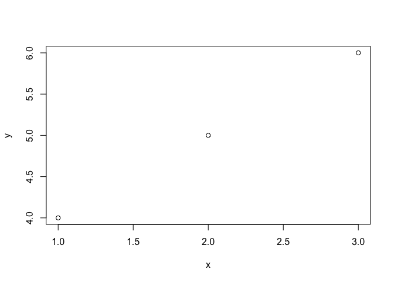

```r
x <- c(1, 2, 3)
y <- c(4, 5, 6)
plot(x,y)
```

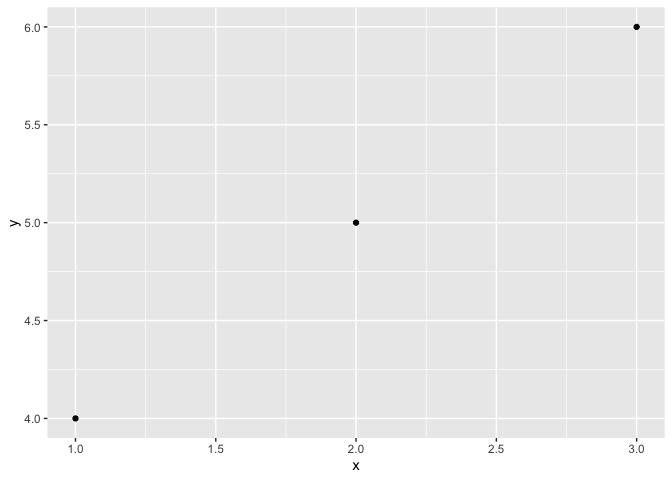

```r
library(ggplot2)
x <- c(1, 2, 3)
y <- c(4, 5, 6)
df <- data.frame(x,y)
ggplot(data=df, aes(x=x,y=y)) + geom_point()
```

## PART 2: Organization Is Key

**File Structure:** I cannot stress this one enough. *Please* don’t just dump your files onto your desktop or into the downloads folder. Folders and subfolders dedicated to a single use will be easier to manage and keep you less stressed. Here’s an example of how I’d structure my folders for the semester:

- 2020Fall  
+ STA532  
- ENV710  
+ Lab1  
+ Lab2  
- Lab3  
Lab3.pdf  
Lab3.Rmd

**Code Structure:** Here’s an example of how I usually structure my files. You don’t have to follow this method exactly, but having a similar structure across scripts can be a helpful tool to make your programming more uniform and easy to read:

```r
# ExampleScript.R
# Created: 04 Aug 2020
# Author:  Margaret Swift [mes114@duke.edu]

# This script is just an example of how to structure your code; you can (and
# should) come up with your own way of doing things.

###############################################################################
# Set up workspace
###############################################################################

rm(list=ls()) #clear all variables in environment for a fresh start
pacman::p_load('ggplot2') #pacman installs packages you may not already have.
dir <- dirname(rstudioapi::getSourceEditorContext()$path) #get current folder
setwd(dir) #set working directory to current folder

###############################################################################
# Do something
###############################################################################

# Indenting inside curly braсes helps with file readability. It's not required
# in R, but it is a good habit to get into.
special_numbers <- c(1, 2, 5)
for ( number in 1:10 ) {
  if ( number %in% special_numbers ) {
    print(paste(number, 'is special!'))
  }
}

###############################################################################
# Save results at the end
###############################################################################

filename <- "results.txt"
write.table('hello world', filename)
```

When you’re ready, move on to the next: “Help, Something’s Broken!”, in a file called “05_HelpSomethingsBroken.html”.